# HW 4 Computer Vision

This assignment is designed to assess your understanding of key concepts in Stereo Vision detection.

Submission Guidelines:

- Notebook Submission: Complete your solutions within this notebook.
- PDF Submission: Export your completed notebook as a PDF and submit it alongside the notebook.

**Important Notes:**

- Submissions without a PDF le will incur a 10% penalty on the total grade.
- Ensure that your code runs without errors and that all visual outputs are included in the PDF.
- Write clear and concise explanations for your code and make sure to add comments in each part of your code.
- Code with no comments will lose 10% of the question mark. Properly format your code and comments to enhance readability.

## Part 1 MCQs (15 marks)

**Q1.** What is the primary function of the pinhole camera model in stereo vision?

a) Increase light exposure  
b) Project 3D scene points onto a 2D image plane  
c) Eliminate lens distortion  
d) Calibrate color mapping

**Ans:** B

**Q2.** What is the disadvantage of having a very small pinhole?

a) It causes blurring  
b) It overexposes the image  
c) It lets in less light  
d) It removes depth information

**Ans:** C

**Q3.** Which matrix encodes the rotation and translation between two views?

a) Homography matrix  
b) Fundamental matrix  
c) Essential matrix  
d) Intrinsic matrix

**Ans:** C

**Q4.** What does the Essential Matrix map?

a) Points to points  
b) Lines to points  
c) Points to lines  
d) Points to planes

**Ans:** C

**Q5.** The fundamental matrix differs from the essential matrix in that it accounts for:

a) Lens distortion  
b) Intrinsic parameters  
c) Extrinsic parameters  
d) Homogeneous coordinates

**Ans:** B

**Q6.** What is the minimum number of point correspondences needed to compute the essential matrix using the 8-point algorithm?

a) 4  
b) 6  
c) 8  
d) 12

**Ans:** C

**Q7.** What is the goal of image rectification?

a) Convert image to grayscale  
b) Make images identical  
c) Align epipolar lines horizontally  
d) Blur the background

**Ans:** C

**Q8.** Which of the following is used for computing depth in stereo vision?

a) Feature maps  
b) Disparity maps  
c) Color histograms  
d) Optical flow

**Ans:** B

**Q9.** Disparity is inversely proportional to:

a) Brightness  
b) Camera calibration  
c) Depth  
d) Focal length

**Ans:** C

**Q10.** Which Opencv2222 function helps estimate the 3D structure from matched points?

a) `cv2.stereoRectify()`  
b) `cv2.findContours()`  
c) `cv2.StereoBM_create()`  
d) `cv2.triangulatePoints()`

**Ans:** D

**Q11.** What does the projection matrix of a camera consist of?

a) Only intrinsic matrix  
b) Intrinsic and extrinsic parameters  
c) Only rotation matrix  
d) Only translation vector

**Ans:** B

**Q12.** Dense reconstruction differs from sparse reconstruction because:

a) It uses a different matrix  
b) It reconstructs only background pixels  
c) It computes depth for all pixels  
d) It skips rectification

**Ans:** C

**Q13.** What type of points are typically used in sparse 3D reconstruction?

a) Random pixels  
b) SIFT keypoints  
c) Disparity vectors  
d) Color-matched pixels

**Ans:** B

**Q14.** The formula `F = K2^(-T) E K1^(-1)` computes:

a) Camera matrix  
b) Homography  
c) Fundamental matrix  
d) Essential matrix

**Ans:** C

**Q15.** What is the main idea behind block matching in depth map estimation?

a) Apply a filter to the disparity  
b) Match color histograms  
c) Match pixel blocks along the x-axis  
d) Compute histograms over the entire image

**Ans:** C

## Part 2 Coding Tasks (10 marks each)

### Q1 (10 marks)

Objective: Estimate the disparity map from a stereo image pair using block matching.

You are provided with a stereo image pair (im0.png, im1.png) from the artroom1 scene.

You will use the built-in `cv2.StereoBM_create()` method, which internally uses the Sum of Absolute Differences (SAD):

$$ \text{SAD}(d) = \sum_{i=-k}^{k} \sum_{j=-k}^{k} \left| I_L(x+i, y+j) - I_R(x - d + i, y + j) \right| $$

**Instructions**

1. Load left and right images in grayscale (1 mark)
2. Correct use of StereoBM_create() with valid parameters (2 marks)
3. Compute disparity with .compute() (2 marks)
4. Normalize and visualize the disparity (3 marks)
5. Clean, readable, and commented code (2 marks)

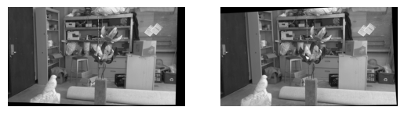

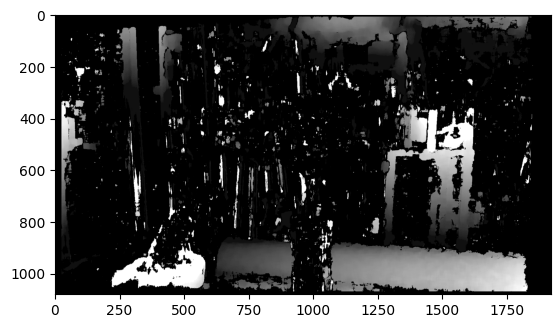

```python
import cv2
import numpy as np
import matplotlib.pyplot as plt

#Load the stereo images in grayscale
img1 = cv2.imread('./HW4 inputs/im0.png', cv2.IMREAD_GRAYSCALE)
img2 = cv2.imread('./HW4 inputs/im1.png', cv2.IMREAD_GRAYSCALE)

sift = cv2.SIFT_create()
# find the keypoints and descriptors with SIFT
kp1, des1 = sift.detectAndCompute(img1,None)
kp2, des2 = sift.detectAndCompute(img2,None)

# Create BFMatcher (Brute Force Matcher)
bf = cv2.BFMatcher()
matches = bf.knnMatch(des1,des2, k=2)

pts1 = []
pts2 = []
# ratio test as per Lowe's paper
for i,(m,n) in enumerate(matches):
 if m.distance < 0.8*n.distance:
     pts1.append(kp1[m.queryIdx].pt)
     pts2.append(kp2[m.trainIdx].pt)

# Finding Fundamental matrix
pts1_ = np.array(pts1)
pts2_ = np.array(pts2)
F, mask = cv2.findFundamentalMat(pts1_, pts2_, cv2.RANSAC)

# We select only inlier points
pts1_ = pts1_[mask.ravel()==1]
pts2_ = pts2_[mask.ravel()==1]

h,w = img1.shape
# find the two homographies
_, H1, H2 = cv2.stereoRectifyUncalibrated(pts1_, pts2_, F, (w,h))
# Appling the two homographies to the two images to rectify them
rectified_img1 = cv2.warpPerspective(img1, H1, (w,h), flags=cv2.INTER_LINEAR)
rectified_img2 = cv2.warpPerspective(img2, H2, (w,h), flags=cv2.INTER_LINEAR)


# Plots
plt.subplot(121),plt.imshow(rectified_img1, cmap='gray'), plt.axis('off')
plt.subplot(122),plt.imshow(rectified_img2, cmap='gray'), plt.axis('off')
plt.show()

# Create a StereoBM object with valid parameters
stereo = cv2.StereoBM_create(numDisparities=16, blockSize=21)

# Compute the disparity map
disparity = stereo.compute(rectified_img1,rectified_img2)

# Normalize the disparity map for visualization
disparity_normalized = cv2.normalize(disparity, None, alpha=0, beta=255, norm_type=cv2.NORM_MINMAX, dtype=cv2.CV_8U)

# Visualize the disparity map
plt.imshow(disparity_normalized,'gray')
```

### Q2 (10 marks)

Compute the depth map from a disparity map using camera calibration parameters.

You are given:

A disparity map (disp0.pfm)

The calibration file (calib.txt) containing the focal length and baseline

Use the formula:

$$ \text{Depth}(x, y) = \frac{f \cdot B}{d(x, y)} $$

 **Instructions:**

1. Load disparity map (1 mark)
2. Parse and extract focal length + baseline (4 marks)
3. Apply depth formula with safe division (3 marks)
4. Visualize or display depth map (2 marks)

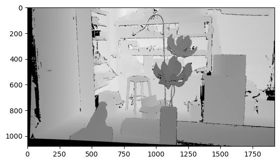

```python
import cv2
import numpy as np

# Load the disparity map
import matplotlib.pyplot as plt

disparity = cv2.imread('./HW4 inputs/disp0.pfm', cv2.IMREAD_UNCHANGED)

# Parse the calibration file to extract focal length and baseline
with open('./HW4 inputs/calib.txt', 'r') as f:
    lines = f.readlines()
    for line in lines:
        if 'baseline' in line:
            baseline = float(line.split('=')[1].strip())
    # Extract focal length from the cam0 matrix
    for line in lines:
        if 'cam0' in line:
            cam0_matrix = line.split('=')[1].strip('[]\n').split(';')[0]
            focal_length = float(cam0_matrix.split()[0])
            break

# Compute the depth map using the formula Depth(x, y) = (f * B) / d(x, y)
# Avoid division by zero by replacing zero disparities with a small value
epsilon = 1e-6
disparity[disparity == 0] = epsilon
depth = (focal_length * baseline) / disparity


# Visualize the depth map in grayscale
plt.imshow(depth, cmap='gray')
```